# `MADloy`: Detecting mosaic loss of Y events using genotype-array-intensity data

Marcos Lopez-Sanchez and Juan R. Gonzalez

Institute for Global Health (ISGlobal), Barcelona, Spain Bioinformatics Research Group in Epidemiolgy (BRGE) (http://www.creal.cat/brge.htm)

26 junio 2017

#### Package version: MADloy 0.9.5.30

# 1 Introduction

`MADloy` is a package to detect mosaic loss of chromosome Y (LOY) events from genotype-array-intensity data. This vignette illustrates how to obtain summarized log R ratio (LRR) values of SNPs probes in the male-specific region of chromosome Y (mLRR-Y) of a set of samples. The mLRR-Y is located in the 56-Mb region between pseudoautosomal regions 1 and 2 (PAR1 and PAR2) on chromosome Y (chrY:2,694,521-59,034,049, hg19/GRCh37). The median value of mLRR-Y can be use as a quantitative proxy of LOY. Downstream association analyses can be performed by regressing median mLRR-Y values with quantitative (e.g. age, gene expression, …) or qualitative (e.g., case/control, smoking, …) traits. The p-values of those regression models can be used values to establish correlations between LOY and traits. Another strategy consists on performing calling of LOY samples by using median mLRR-Y and then associate this binary variable (normal/LOY) with the trait of interest. This will be addressed in a different vignette.

# 2 Getting started

You can install `MADloy` from Github by typing

```r
devtools::install_github("isglobal-brge/MADloy_v1")
```

Then the package is loaded as usual

```r
library(MADloy)
```

We have prepared a set of data files including 124 males and 2 females to be used as an illustrative example about how to get mLRR-Y data of each sample. Files and data have been anonymized and belong to individuals from general population. These files can be downloaded from this link [LOYdata](https://goo.gl/tZu2Pt) - https://goo.gl/tZu2Pt.

The zipped file includes one file per sample in the required format to be processed with `MADloy` package. This format is described in the next section.

In order to reproduce this vignette, decompress the .zip file in a folder and set this folder path in an R object (for instance `rawDataPath`).

```r
rawDataPath <- "/SYNCRW10125/DATASETS/STUDY/EGCUT/rawData_anon"
rawDataPath
```

```
## [1] "/SYNCRW10125/DATASETS/STUDY/EGCUT/rawData_anon"
```

```r
files <- dir(rawDataPath)
length(files)
```

```
## [1] 126
```

```r
files[1:5]
```

```
## [1] "FEMALE_2291.txt" "FEMALE_2439.txt" "SAMPLE_100.txt"  "SAMPLE_101.txt"
## [5] "SAMPLE_102.txt"
```

# 3 Processing SNP data with `madloy`: loading and summarizing LRR (and BAF)

## 3.1 Required input data

The function `madloy` processes individual SNP array data in [pennCNV format](http://penncnv.openbioinformatics.org/en/latest/user-guide/input/). Basically, different files of each sample must be created containing information about SNP, chromosome, position, LRR, BAF and genotype (although having only the first 4 columns is enough to summarized mLRR-Y). Different tools can be used to get the required information. Affymetrix data (.CEL files) can be processed by using [Birdseed v2 algorithm](http://archive.broadinstitute.org/mpg/birdsuite/birdseed.html). [Affymetrix power tools](https://www.affymetrix.com/support/developer/powertools/changelog/index.html) can also be used to process .CEL files as well as [affy2sv R package](https://bitbucket.org/brge/affy2sv/wiki/Home). Illumina data (.idat files) can be processed by using [Genome Studio software](https://www.illumina.com/techniques/microarrays/array-data-analysis-experimental-design/genomestudio.html). crlmm Bioconductor package can also be used to get LRR and BAF.

## 3.2 Filtering female samples

LOY association studies are performed only using male samples. Obviously, clinical data can be used to filter such individuals. However, in some ocassions there are errors in those databases that can be detected by using genomic data. The function `checkSex` can be used to further verify that there are no female samples in our data. Let us perform this filtering using HapMap data

```r
sex <- checkSex(rawDataPath, mc.cores=20)
```

```
## Processing 126 file(s)...
```

This function only requires the path containing the raw data in pennCNV format. By default the function is assuming that the LRR information is in column number 4. This can be changed through the argument `LRRCol`. Notice that this function speed up the process by changing the argument `mc.cores`.

The function `checkSex` returns an object that can be plotted by using the generic function `plot`. The figure depicts the LRR in both X and Y chromosomes.

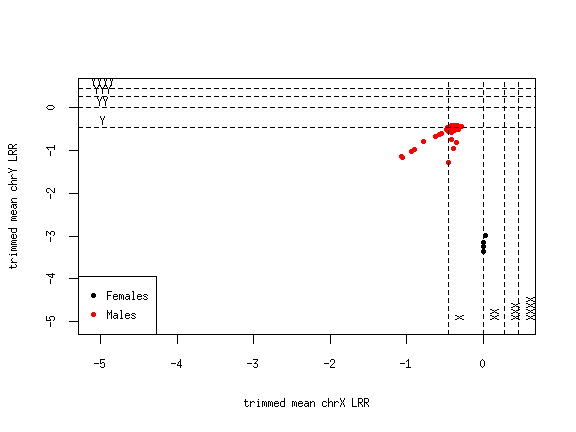

```r
plot(sex)
```

This figure shows that there are 4 female samples, although only 2 were identified as female in the epidemiological data. This information can also be seen by typing

```r
sex
```

```
## Object of class checkSex
## ----------------------------
## Number of processed samples: 126
## Number of female classified samples:  4
## Number of male classified samples:  122
```

These samples can be identified

```r
sex$par$files[sex$class=="FEMALE"]
```

```
## [1] "/SYNCRW10125/DATASETS/STUDY/EGCUT/rawData_anon/FEMALE_2291.txt"
## [2] "/SYNCRW10125/DATASETS/STUDY/EGCUT/rawData_anon/FEMALE_2439.txt"
## [3] "/SYNCRW10125/DATASETS/STUDY/EGCUT/rawData_anon/SAMPLE_4.txt"
## [4] "/SYNCRW10125/DATASETS/STUDY/EGCUT/rawData_anon/SAMPLE_88.txt"
```

and removed from the next analyses by selecting the files corresponding to males samples:

```r
files.males <- sex$par$files[sex$class!="FEMALE"]
```

## 3.3 Data normalization

Summarized (median) mLRR-Y data is used as a proxy of LOY events. The median mLRR-Y value can be affected by several artifacts that have to be corrected before analyzing mLRR-Y data. First, it can be a systematic bias in the mLRR-Y due to the fact that the overall intensity of LRR distribution shifted slightly away from 0 in the whole array. This issue is addressed by normalizing the median mLRR-Y data using the LRR intensity in the autosomes (reference). In particular, we propose to compute the 5% trimmed-mean of LRR to avoid regions having copy number alterations. This parameter can be tuned to take into account the different nature of the data we are dealing with. As an example, studies in cancer are expected to have individuals with large number of aneuploidies. Therefore, the trimmed value of the LRR may be increased up to, for instance, 25%.

Second, some of the existing algorithms used to get LRR information do not normalize the intensity of mLRR-Y to be 0. They provide values close to -0.46 indicating that only 1 copy is present in males (e.g ploidy is equal to 1) and hence, the LRR is centered at 2/3log(1/2) = -0.46. We address this issue by shifting the observed values of mLRR-Y towards 0 by removing the median value of the mLRR-Y in all individuals.

## 3.4 Get summarized mLRR-Y data

`madloy` function processes raw data (e.g. separate files in pennCNV format of each sample) and provides the normalized median mLRR-Y value of each sample. The normalization procedure consists on considering technical artifacts that may affect the LRR values in the mLRR-Y region by removing:

> - The sample mean-trimmed LRR values in autosomes
> - The median value of summarized mLRR-Y region of all samples

The `madloy` function is design to process LRR files and only requires the path where those files are located. Let us illustrate how to get summarized data of our illustrative example available at `LOYdata` package (see Getting Started section). NOTE: if `checkSex` is not executed, `files.males` should be replaced by `rawDataPath`

```r
ex <- madloy(files.males, mc.cores=20)
```

```
## Targeted region set to chrY:6671498-22919969 by default
```

```
## Using all autosomes as Reference region
```

```
## LRR median will be computed in all autosomal chromosomes as reference regions and target region chrY:6671498-22919969
```

```
## Processing 122 file(s)...
```

The function creates an object of class `MADloy` that can be inspected by using the generic `print` function.

```r
ex
```

```
## Object of class MADloy
## ----------------------------
## Number of processed samples: 122
## Target region: chrY:6671498-22919969
## Reference region(s): Autosomal chromosomes
## Offset (median LRR value in msY): -0.56
```

We observe that LRR data has been summarized in a target and a reference region. By default the target region corresponds to the mLRR-Y region and the reference region (the one used to normalized LRR in the target region) corresponds to autosomal chromosomes. The arguments `target.region` and `ref.region` can be used to change those values. This information has to be passed in UCSC format (e.g. “chr21” or “chr21:1000-10000”).

By default the human genome reference is `hg18` that can be changed in the argument `hg`. The package also contains files encoding the required information to retrieve summarized data in X and Y PAR regions, p and q arms, and msY region that are used to better describe the characteristics of LOY samples.

The LRR data of the reference is summarized by using the trimmed-mean. The argument `trim` controls the fraction of probes (e.g. LRR values) that are removed from each end before the mean is computed (0 to 0.5). This is a robust summary of LRR in a given region since it takes into account possible regions in the genome having CNV alterations. By default 5% of probes are trimed. This values is recommended to be increased, for instance, when analyzing cancer data where a large number of alterations is expected to be found. In case of being interested in summaryzing LRR data by using the median value, `trim` should be set equal to 0.5.

Samples with bad quality, which is, having large variability in the LRR data are recommended to do not be included in the analysis. Therefore, the function returns NA values of summarized mLRR-Y for those samples having LRR variability larger than 2 times the observed mean standard deviation among samples.